# Annotating Proliferating Modules

2023-05-30

# Goals

Objective here is to annotate the modules with their known funciton and indicate if they have any interesting differential activity across conditions, suggesting they have a differential impact across individuals. This is a continuation of the mod id on 20230529, and is using those three groups of mods:

1. Treatmnet + Timepoint
2. Treatment
3. All cells

In general, the first group is most likely to have an interesting geneset that differentiates the groups but it is also most likely to be noisy, while group three is the opposite.

##exploratory analysis

The objective here is to first identify ones that are interesting across groups, and then go and annotate just those as more interesting vs not. The trick here is to meet criteria that filter out uninteresting stuff.

1. Not driven by just one participant
2. Based on our hypothesis, we expect it to be equal at time 0 and diverge at time 3.

Both of these criteria may be challenging because of the low cell number, so we’ll look at them both in proliferating cells and in an alternative set of cells. For me, I’ll check Central_Memory and Naive_T_1. These are selected mainly to represent the memory and naive background.

```r
mods<-c(unlist(mods1, recursive = F), unlist(mods2, recursive = F), mods3)

#first we score these across all cells

results<-AddModuleScore(results, mods, name = names(mods))
```

```r
results$T_TP<-paste(results$Treatment, results$Timepoint, sep="_")
#then we write a loop that will generate a pdf of the desired plots

for (i in names(results@meta.data)[34:52]){
  pdf(paste0("~/gibbs/DOGMAMORPH/Ranalysis/modules/proliferation/",i,".pdf"))
  print(FeaturePlot(results, i, min.cutoff = 'q5', max.cutoff = 'q95'))
  print(VlnPlot(results, i,idents = "Proliferating", split.by = "T_TP"))
  print(VlnPlot(results, i,idents = "Central_Memory", split.by = "T_TP"))
  print(VlnPlot(results, i,idents = "Naive_T_1", split.by = "T_TP"))
  print(VlnPlot(results, i,idents = "Naive_T_1", split.by = "Participant"))
  print(VlnPlot(results, i,idents = "Naive_T_1", split.by = "orig.ident"))
  dev.off()
  }
```

```
## The default behaviour of split.by has changed.
## Separate violin plots are now plotted side-by-side.
## To restore the old behaviour of a single split violin,
## set split.plot = TRUE.
##
## This message will be shown once per session.
```

## ontology annotation

First, we’ll write each mod to an individual list just to make it easy to use Enrichr (https://maayanlab.cloud/Enrichr/). Initially, I’m just looking at GO processes.

```r
#grab just the interesting ones

mods_interest<-mods[c("Bup.Nalo_0_black","Bup.Nalo_3_blue","Bup.Nalo_green","Naltrexone_0_magenta","Naltrexone_3_brown")]

mods_interest
```

```
## $Bup.Nalo_0_black
##  [1] "TUBA1B"    "SLC25A5"   "TYMS"      "TUBB"      "STMN1"     "TPI1"
##  [7] "PSMA7"     "HIST1H4C"  "TK1"       "LDHA"      "HMGB2"     "TUBB4B"
## [13] "BIRC5"     "CLSPN"     "HNRNPAB"   "MT2A"      "ENO1"      "KIF18B"
## [19] "SPC25"     "MELK"      "CIT"       "ANLN"      "POLQ"      "RAD54L"
## [25] "BRCA2"     "NCAPG2"    "PLK4"      "NUSAP1"    "MASTL"     "KNTC1"
## [31] "BRIP1"     "ASPM"      "BUB1B"     "KIF14"     "CDCA8"     "KIF4A"
## [37] "CKAP2L"    "ESPL1"     "HIST2H2AB" "CKS1B"     "ARHGAP11A" "NCAPH"
## [43] "HJURP"     "KCNQ5"     "CDC45"     "SLBP"      "TIMM13"    "HSPD1"
## [49] "DTL"       "MCM4"      "TRBV5-1"   "FANCA"     "FANCB"     "ATAD5"
## [55] "CENPP"     "EXO1"      "E2F7"      "SLC12A8"   "BRCA1"     "MSH6"
## [61] "FUT7"      "CX3CR1"    "UHRF1"     "WARS2"     "LRRC20"    "ACTL6A"
## [67] "PIGM"
##
## $Bup.Nalo_3_blue
```

[output cut: 69 more lines]

```r
for (i in names(mods_interest)){
  write.table(mods_interest[[i]], file=paste0("~/gibbs/DOGMAMORPH/Ranalysis/modules/proliferation/",i,".txt"), quote = FALSE, row.names = FALSE, col.names = FALSE, sep = "")
}
```

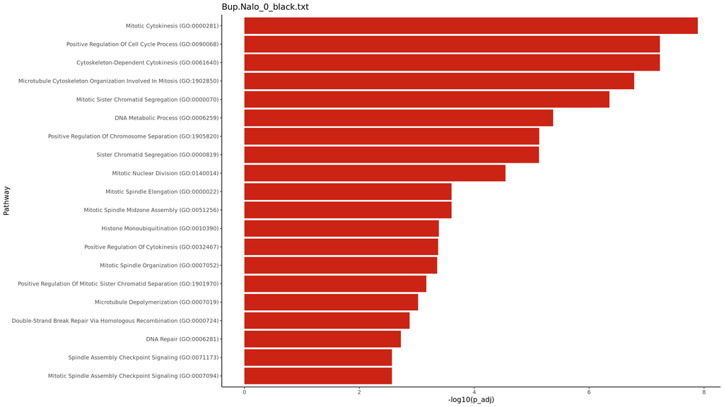

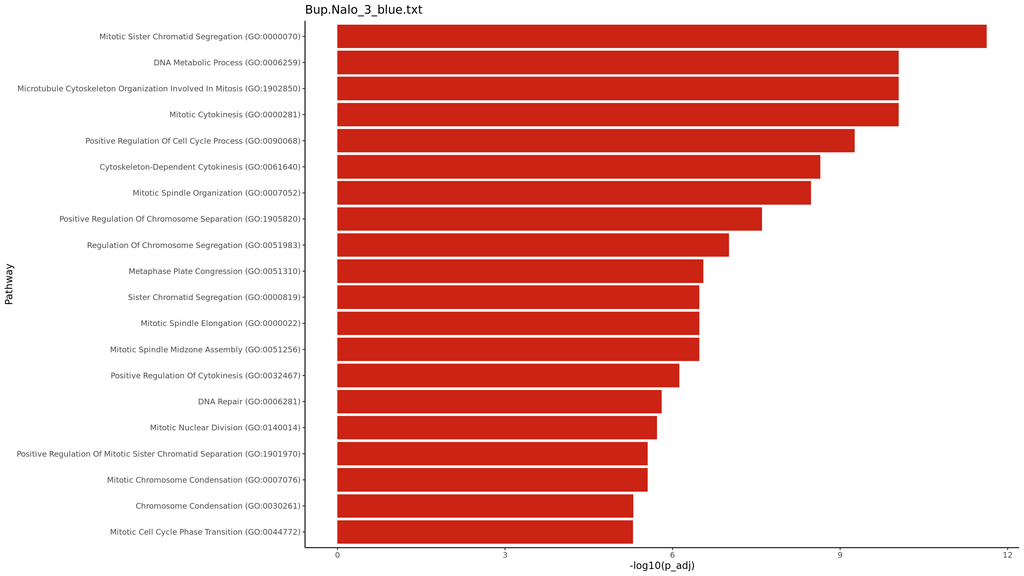

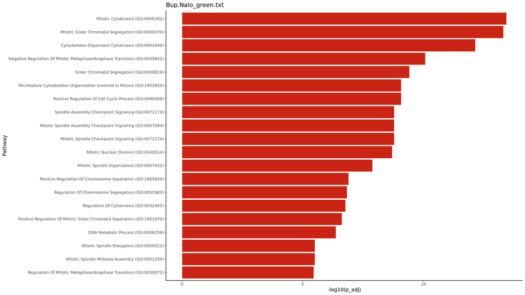

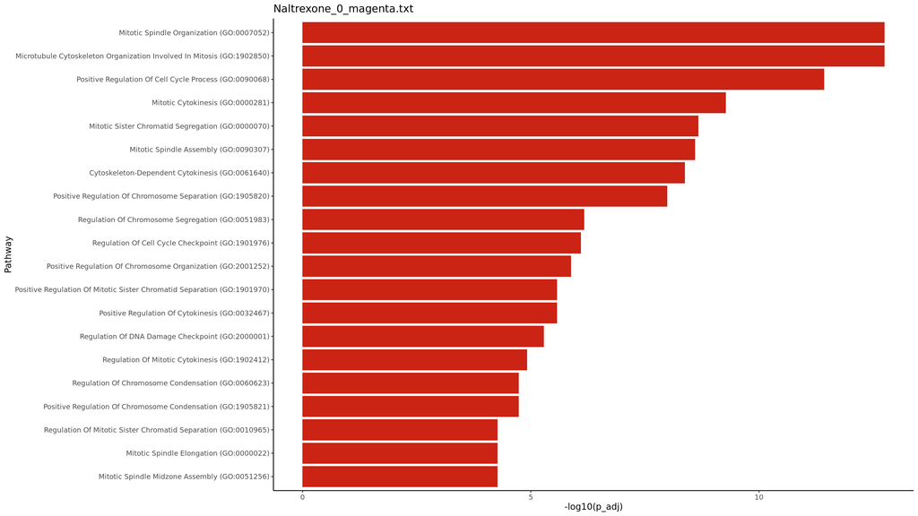

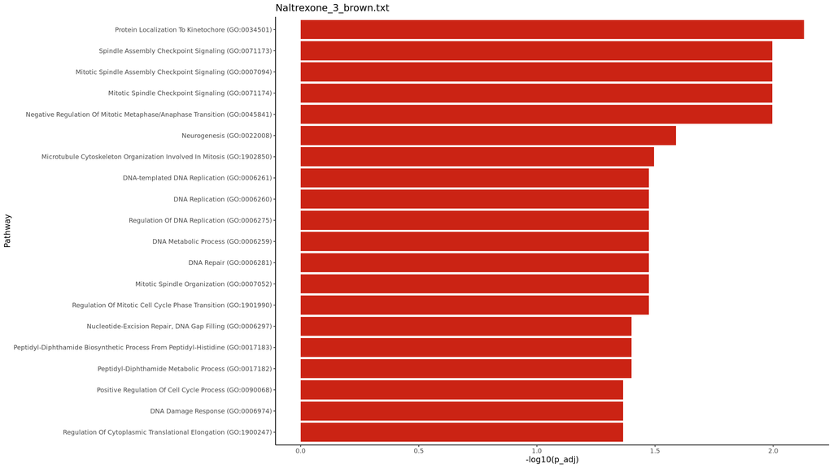

```r
#borrowing some rushmore colors from the wes anderson color pack
BottleRocket2 = c("#FAD510", "#CB2314", "#273046", "#354823", "#1E1E1E")


#defining a quick function to read in and plot Enrichr

PlotEnrichment<-function(file, topn=10, returnplot=TRUE, title="Significant Pathways"){
  data<-read.table(file, sep = "\t", header=1)
  data$value<- -log10(data$Adjusted.P.value)
  #order by most signfiicant
  data$Term<-factor(data$Term, levels = rev(data$Term))
  data<-data[order(data$value, decreasing = TRUE),]
  #subset to top n
  data<-data[1:topn,]
  plot<-ggplot(data, aes(x=value, y=Term))+geom_bar(stat="identity", fill=BottleRocket2[2])+xlab("-log10(p_adj)")+ylab("Pathway")+ggtitle(title)+theme_classic()
  if(returnplot){return(plot)}
  return(data)
}

todo<-list.files("~/gibbs/DOGMAMORPH/Ranalysis/modules/proliferation/enrichr/")

for (i in todo){
  print(PlotEnrichment(paste0("~/gibbs/DOGMAMORPH/Ranalysis/modules/proliferation/enrichr/",i), topn = 20, title=i))
}
```

# Conclusion

Next steps: Modules across CD4 (without those above populations) Batch corrected analysis of total Proliferating